# R Notebook

team members Andres Jimenez ajimenezbonilla1234@floridapoly.edu Allan Gil agil1330@floridapoly.edu

Introduction

Most of us watch Netflix and enjoy watching movies and TV shows on the platform daily. Since Netflix is one of the oldest streaming platforms that are still currently available, how does one select something to watch. Netflix has a huge library of shows and movies to watch which can make this process difficult.

- ```
    What is the average rating based on year?
  ```

- ```
    What Netflix series are only for adults?
  ```

- ```
    What series have the highest ratings?
  ```

Let’s get this answered!

Our final project is for Intro to Data Science summer B class 2021.

```r
library(ggplot2)
library(tidyverse)
```

```r
netflixlink<-"netflixShows.csv"
netflixShows<- read_csv(netflixlink,    col_types = cols(ratingDescription = col_integer(),
        release_year = col_integer(), user_rating_score = col_integer(),
        user_rating_size = col_integer()))
```

```r
glimpse(netflixShows)
```

```
Rows: 1,000
Columns: 7
$ title             <chr> "White Chicks", "Lucky Number Slevin", "Grey's Anatomy", "Prison Break", "How I Met Your Mother", "Supernatural", "Breaking Bad", "The Vampire Diaries", "The Walking Dead", "Pretty Little Liars", "Once Upon a Time", "Sherlock", "Death Note", "Naruto", "The Hunter", "Lottie …
$ rating            <chr> "PG-13", "R", "TV-14", "TV-14", "TV-PG", "TV-14", "TV-MA", "TV-14", "TV-MA", "TV-14", "TV-PG", "TV-14", "TV-14", "TV-P~
$ ratingLevel       <chr> "crude and sexual humor, language and some drug content", "strong violence, sexual content and adult language", "Paren~
$ ratingDescription <int> 80, 100, 90, 90, 70, 90, 110, 90, 110, 90, 70, 90, 90, 70, 100, 10, 90, 110, 90, 124, 10, 110, 124, 124, 110, 110, 110~
$ release_year      <int> 2004, 2006, 2016, 2008, 2014, 2016, 2013, 2017, 2015, 2016, 2016, 2016, 2006, 2008, 2011, 2009, 2015, 2016, 2016, 2016~
$ user_rating_score <int> 82, NA, 98, 98, 94, 95, 97, 91, 98, 96, 98, 95, 77, 88, NA, NA, 96, 80, 74, 97, 81, NA, NA, 57, 95, 98, 94, 98, NA, NA~
$ user_rating_size  <int> 80, 82, 80, 80, 80, 80, 80, 80, 80, 80, 80, 80, 80, 80, 82, 82, 80, 80, 80, 80, 80, 82, 82, 80, 80, 80, 80, 80, 82, 82~
```

```r
colnames(netflixShows)
```

```
[1] "title"             "rating"            "ratingLevel"       "ratingDescription" "release_year"      "user_rating_score" "user_rating_size"
```

```r
summary(netflixShows)
```

```
    title              rating          ratingLevel        ratingDescription  release_year  user_rating_score user_rating_size
 Length:1000        Length:1000        Length:1000        Min.   : 10.00    Min.   :1940   Min.   :55.00     Min.   :80.00
 Class :character   Class :character   Class :character   1st Qu.: 35.00    1st Qu.:2007   1st Qu.:75.00     1st Qu.:80.00
 Mode  :character   Mode  :character   Mode  :character   Median : 60.00    Median :2015   Median :88.00     Median :80.00
                                                          Mean   : 67.37    Mean   :2010   Mean   :84.09     Mean   :80.78
                                                          3rd Qu.: 90.00    3rd Qu.:2016   3rd Qu.:95.00     3rd Qu.:82.00
                                                          Max.   :124.00    Max.   :2017   Max.   :99.00     Max.   :82.00
                                                                                           NA's   :395
```

different ratings the table below depicts the different age ratings and what they mean

```r
 rating_meaning<- netflixShows %>%
  select(rating, ratingLevel )
distinct(rating_meaning)
```

| rating | ratingLevel |
| --- | --- |
| PG-13 | crude and sexual humor, language and some drug content |
| R | strong violence, sexual content and adult language |
| TV-14 | Parents strongly cautioned. May be unsuitable for children ages 14 and under. |
| TV-PG | Parental guidance suggested. May not be suitable for all children. |
| TV-MA | For mature audiences. May not be suitable for children 17 and under. |
| R | language and brief violence |
| TV-Y | Suitable for all ages. |
| NR | This movie has not been rated. |
| TV-MA | NA |
| TV-Y7-FV | Suitable for children ages 7 and older. Content contains fantasy violence. |

[output cut: 95 more lines]

```r
NA
```

this chart depicts all of the different shows streaming and what there age rating is

```r
netflixShows %>%
select(title,rating ) %>%
group_by(rating ) %>%
arrange(rating)
```

| title | rating |
| --- | --- |
| Hannah Montana: The Movie | G |
| Hannah Montana: The Movie | G |
| Chicken Little | G |
| The Smurfs and the Magic Flute | G |
| We're Back! A Dinosaur's Story | G |
| An Extremely Goofy Movie | G |
| Super Buddies | G |
| Growing Up Wild | G |
| Tarzan | G |
| The Emperor's New Groove | G |

[output cut: 990 more lines]

```r
NA
```

this chart shows the different rating description

```r
netflixShows %>%
  distinct(ratingDescription)
```

| ratingDescription |
| --- |
| 80 |
| 100 |
| 90 |
| 70 |
| 110 |
| 10 |
| 124 |
| 42 |
| 60 |
| 35 |

[output cut: 1 more lines]

this next plot chart shows the corraltion beteen user ratings and the avergae release date

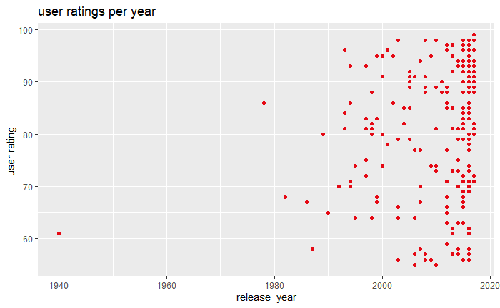

```r
 ggplot(netflixShows ,aes(x= release_year,y=user_rating_score,  )) +
  geom_point( color="#E50914",fill="#E50914")+
  labs(title = "user ratings per year ",
       x = "release  year",
       y = "user rating ",)
```

```r
netflixShows %>%
  select(release_year,user_rating_score) %>%
  group_by(release_year) %>%
  summarise(averageRating = mean(user_rating_score,na.rm = TRUE))
```

| release_year | averageRating |
| --- | --- |
| 1940 | 61.00000 |
| 1976 | NaN |
| 1978 | 86.00000 |
| 1982 | 68.00000 |
| 1986 | 67.00000 |
| 1987 | 58.00000 |
| 1989 | 80.00000 |
| 1990 | 65.00000 |
| 1991 | NaN |
| 1992 | 70.00000 |

[output cut: 25 more lines]

this chart shoes the age rating of movies released each year

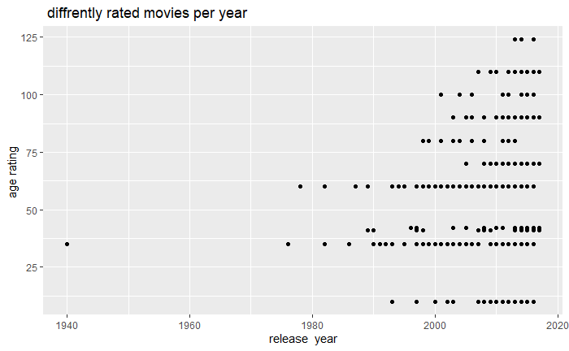

```r
ggplot(data=ratings_1,aes(y= ratingDescription,x= release_year, color= rating)) +
geom_point(color="black",binwidth=5)+
  labs(title = " diffrently rated movies per year ",
       x = "release  year",
       y = "age rating ",
       size = "age rating")
```

how many movies Netflix has per release year

```r
select(netflixShows, title, release_year) %>%
  group_by(release_year) %>%
  count(release_year)
```

| release_year | n |
| --- | --- |
| 1940 | 3 |
| 1976 | 4 |
| 1978 | 2 |
| 1982 | 6 |
| 1986 | 4 |
| 1987 | 2 |
| 1989 | 2 |
| 1990 | 7 |
| 1991 | 5 |
| 1992 | 2 |

[output cut: 25 more lines]

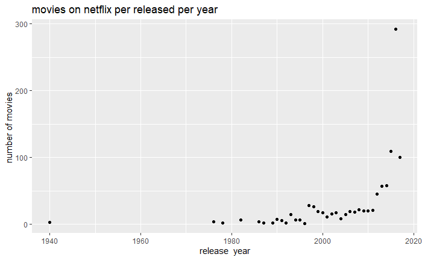

```r
ggplot(titlenum, aes(y=n,x=release_year))+
  geom_point()+
  labs(title = "movies on netflix per released per year ",
       x = "release  year",
       y = "number of movies ",
       size = "")
```

what are the newest Netflix series are most suitable for children under 13?

```r
netflixShows %>%
  select(title, rating, ratingLevel, ratingDescription,release_year) %>%
  filter(ratingDescription <=70) %>%
  arrange(desc(release_year))%>%
  summarize(title, rating, ratingLevel)
```

| title | rating | ratingLevel |
| --- | --- | --- |
| One Day at a Time | TV-PG | Parental guidance suggested. May not be suitable for all children. |
| Dinotrux | TV-Y7-FV | Suitable for children ages 7 and older. Content contains fantasy violence. |
| Edgar Rice Burroughs' Tarzan and Jane | TV-Y7-FV | Suitable for children ages 7 and older. Content contains fantasy violence. |
| Dinotrux | TV-Y7-FV | Suitable for children ages 7 and older. Content contains fantasy violence. |
| Edgar Rice Burroughs' Tarzan and Jane | TV-Y7-FV | Suitable for children ages 7 and older. Content contains fantasy violence. |
| Voltron: Legendary Defender | TV-Y7-FV | Suitable for children ages 7 and older. Content contains fantasy violence. |
| Buddy Thunderstruck | TV-PG | Parental guidance suggested. May not be suitable for all children. |
| Dragons: Race to the Edge | TV-Y7-FV | Suitable for children ages 7 and older. Content contains fantasy violence. |
| Dawn of the Croods | TV-Y7 | Suitable for children ages 7 and older |
| Dinotrux | TV-Y7-FV | Suitable for children ages 7 and older. Content contains fantasy violence. |

[output cut: 559 more lines]

there are total of 569 netflix series suitable for childern under 13.

what year has the the most movies with the highest average rating

```r
netflixShows %>%
 select(release_year, user_rating_score,title) %>%
  group_by(release_year) %>%
  mutate(average_rating_per_year =mean(user_rating_score ,na.rm=TRUE))
```

| release_year | user_rating_score | title | average_rating_per_year |
| --- | --- | --- | --- |
| 2004 | 82 | White Chicks | 83.50000 |
| 2006 | NA | Lucky Number Slevin | 72.66667 |
| 2016 | 98 | Grey's Anatomy | 86.83500 |
| 2008 | 98 | Prison Break | 87.18750 |
| 2014 | 94 | How I Met Your Mother | 78.00000 |
| 2016 | 95 | Supernatural | 86.83500 |
| 2013 | 97 | Breaking Bad | 80.42308 |
| 2017 | 91 | The Vampire Diaries | 90.42623 |
| 2015 | 98 | The Walking Dead | 84.50000 |
| 2016 | 96 | Pretty Little Liars | 86.83500 |

[output cut: 990 more lines]

2017 has the highest average ratings

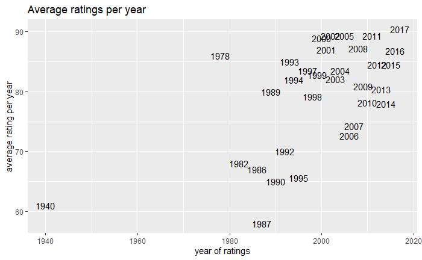

```r
netflixShows %>%
  select(release_year, user_rating_score,title) %>%
  group_by(release_year) %>%
  summarise(average_rating_per_year =mean(user_rating_score ,na.rm=TRUE)) %>%
  ggplot()+
  geom_text(aes(y=average_rating_per_year,x=release_year,label=release_year))+
  labs(x= "year of ratings",y= "average rating per year",title = "Average ratings per year" )
```

How many netflix series have a user rating score below a 60?

```r
netflixShows %>%
  select(release_year, user_rating_score, title) %>%
  filter(user_rating_score < 60)
```

| release_year | user_rating_score | title |
| --- | --- | --- |
| 2013 | 57 | Hunter X Hunter (2011) |
| 2012 | 59 | Absolutely Fabulous |
| 2016 | 58 | Haters Back Off |
| 2010 | 55 | Life Unexpected |
| 2014 | 58 | Being Human (U.S.) |
| 2003 | 56 | How to Lose a Guy in 10 Days |
| 2007 | 58 | High School Musical 2 |
| 2009 | 56 | Hannah Montana: The Movie |
| 2007 | 58 | High School Musical 2 |
| 2009 | 56 | Hannah Montana: The Movie |

[output cut: 17 more lines]

A total of 27 Netflix series have a user rating lower than 60.

How many Netflix series have not been rated?

```r
netflixShows %>%
  select(release_year, rating, title) %>%
  filter(rating == "NR")
```

| release_year | rating | title |
| --- | --- | --- |
| 2016 | NR | The 100 |
| 2013 | NR | Nymphomaniac: Volume 1 |
| 2013 | NR | Hunter X Hunter (2011) |
| 2014 | NR | Sex, Love and Therapy |
| 2016 | NR | Stronger Than the World |
| 2016 | NR | Back and Forth |
| 2016 | NR | The 100 |
| 2016 | NR | Almost Adults |
| 2014 | NR | Honeytrap |
| 2016 | NR | Like Cotton Twines |

[output cut: 4 more lines]

A total of 14 Netflix series have not been rated.

How Many Netflix series have a rating description greater than a 100?

```r
netflixShows %>%
  select(title, rating, ratingDescription) %>%
  filter(ratingDescription > 100)
```

| title | rating | ratingDescription |
| --- | --- | --- |
| Breaking Bad | TV-MA | 110 |
| The Walking Dead | TV-MA | 110 |
| Black Mirror | TV-MA | 110 |
| The 100 | NR | 124 |
| Pai, - Look at This | TV-MA | 110 |
| Nymphomaniac: Volume 1 | NR | 124 |
| Hunter X Hunter (2011) | NR | 124 |
| Marvel's Luke Cage | TV-MA | 110 |
| Marvel's Iron Fist | TV-MA | 110 |
| Narcos | TV-MA | 110 |

[output cut: 153 more lines]

A total of 163 Netflix series have a rating description greater than a 100.

conclusion After our data exploration, we were able to gain some insight into how release year, and content rating, affect the review scores. This project has helped me and my team adapt to an online environment and github has helped with this process. In this project we further learned important R skills.

future works there is more work to be done such as matching the average watch time to how the users rated the show for example this could show you how the user rated a show or movie and whether they finished it or not and use that correlation to see whether people who finished the show rated it higher than the people who did not finish. another thing you could do is find out how long certain shows or moves are and see how many people are watching those shows versus shows or moves of the same genre with different lengths. these questions and others help Netflix maximize profits on licensing contracts as well as help recommend shows for people to watch as well as help people decide what to watch.

data sets cited thank you professor Rei Sanchez-Arias for providing the netflix data set

Netflix data set: https://github.com/reisanar/datasets/blob/4598573c75313d32076ea86e086f2d617d9fac8f/netflixShows.csv